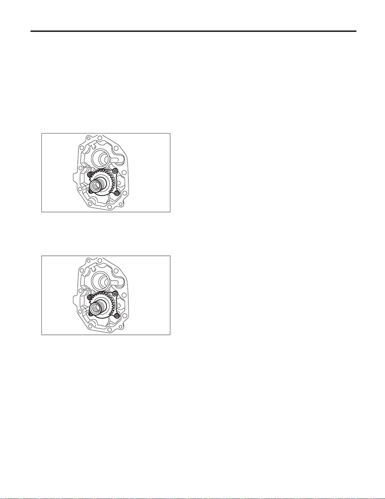

Transfer Drive Gear

MANUAL TRANSMISSION AND DIFFERENTIAL

11.Transfer Drive Gear

A: REMOVAL

1) Remove the manual transmission assembly from the vehicle. <Ref. to 6MT(TY75)-25, REMOVAL, Manual

Transmission Assembly.>

2) Remove the back-up light switch and the neutral position switch. <Ref. to 6MT(TY75)-45, REMOVAL,

Switches and Harness.>

3) Remove the transfer case together with the extension case assembly. <Ref. to 6MT(TY75)-51, REMOV-

AL, Transfer Case and Extension Case Assembly.>

4) Remove the extension case assembly.

5) Remove the transfer driven gear. <Ref. to 6MT(TY75)-65, REMOVAL, Transfer Driven Gear.>

6) Remove the transfer drive gear.

B: INSTALLATION

1) Install the transfer drive gear.

Tightening torque:

26 N·m (2.7 kgf-m, 19.2 ft-lb)

2) Install the transfer driven gear. <Ref. to 6MT(TY75)-66, INSTALLATION, Transfer Driven Gear.>

3) Select the adjusting washer. <Ref. to 6MT(TY75)-53, INSTALLATION, Transfer Case and Extension Case

Assembly.>

4) Install the extension case assembly. <Ref. to 6MT(TY75)-53, INSTALLATION, Transfer Case and Exten-

sion Case Assembly.>

5) Install the transfer case and the extension case assembly. <Ref. to 6MT(TY75)-53, INSTALLATION,

Transfer Case and Extension Case Assembly.>

6) Install the back-up light switch and the neutral position switch. <Ref. to 6MT(TY75)-46, INSTALLATION,

Switches and Harness.>

7) Install the manual transmission assembly to the vehicle. <Ref. to 6MT(TY75)-30, INSTALLATION, Manual

Transmission Assembly.>

MT-02460

MT-02460

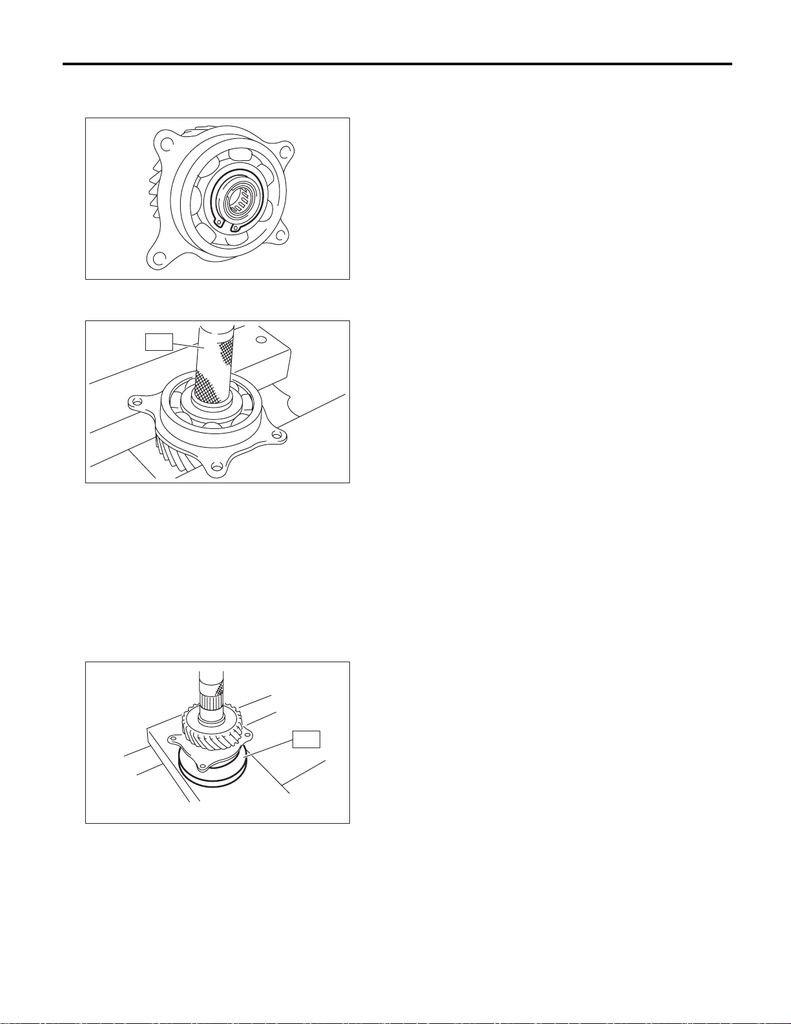

Transfer Drive Gear

MANUAL TRANSMISSION AND DIFFERENTIAL

C: DISASSEMBLY

1) Remove the snap ring.

2) Remove the ball bearing.

ST 899864110 REMOVER

3) Remove the snap ring from transfer drive gear, and remove the needle bearing.

D: ASSEMBLY

1) Install the needle bearing and snap ring to the transfer drive gear.

2) Set the ST to the ball bearing inner race, then install the transfer drive gear.

CAUTION:

Do not apply a load in excess of 10 kN (1 ton, 1.1 US ton, 1.0 Imp ton).

NOTE:

Use a new ball bearing.

ST 398177700 INSTALLER

MT-01967

MT-01969

ST

MT-01970

ST

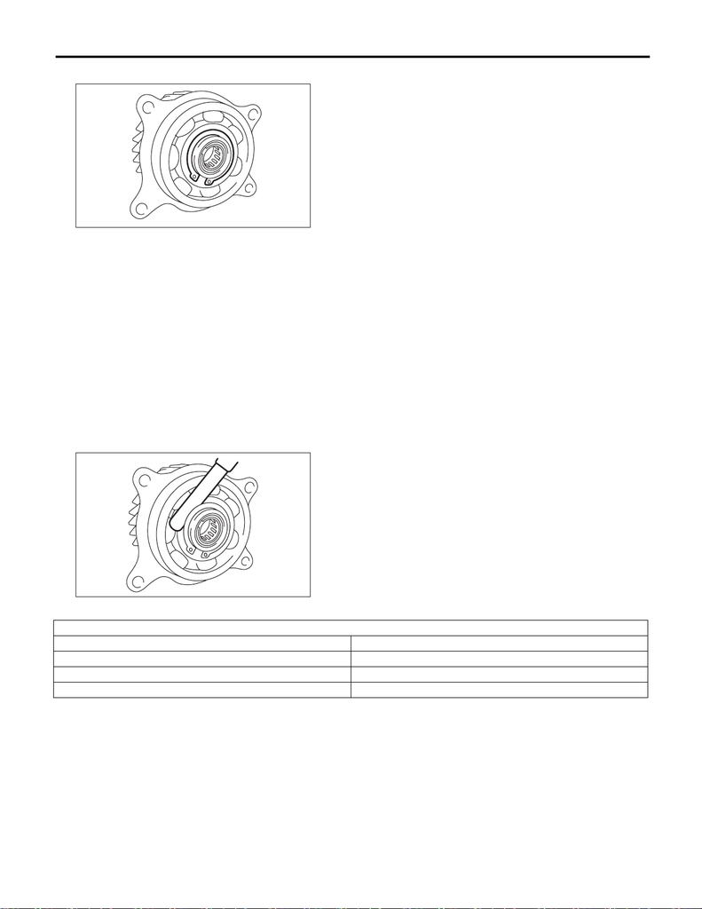

Transfer Drive Gear

MANUAL TRANSMISSION AND DIFFERENTIAL

3) Install the snap ring.

4) Inspect the clearance between the snap ring and the ball bearing. <Ref. to 6MT(TY75)-64, INSPECTION,

Transfer Drive Gear.>

E: INSPECTION

1) Ball bearing

Replace the ball bearing in following cases.

• In case of broken or rusty ball bearings

• In case of worn or damaged ball bearings

• When the ball bearings fail to turn smoothly or emit noise in rotation after gear oil lubrication.

2) Transfer drive gear

If the tooth face of transfer drive gear and the shaft are excessively broken or damaged, replace the transfer

drive gear.

3) Measure the clearance between snap ring and inner race of ball bearing with a thickness gauge.

Clearance:

0.01 — 0.15 mm (0.0004 — 0.0059 in)

If the measurement is not within specification, select a suitable snap ring and replace it.

MT-01967

MT-01968

Snap ring (outer-30)

Part No. Thickness mm (in)

805030041 1.53 (0.0602)

805030042 1.65 (0.0650)

805030043 1.77 (0.0697)